# Travail pratique de représentation des données 2021-2022

## réalisé par Mulapi Tita Ketsia

```python
!pip install opencv-python
```

```python
!pip install scikit-image
```

## Importation des libraires

```python
from skimage import filters
from skimage import data, io, morphology
from skimage.io import imread
import matplotlib.pyplot as plt
import numpy as np
import io
import cv2
from scipy.ndimage.measurements import label
from skimage.filters import sobel
from skimage import measure
from skimage.segmentation import clear_border, watershed
from skimage.color import label2rgb
```

# Partie 1. Seuillage d'images avec Otsu et composantes connexes

Quoi ?

L'objectif de cette partie est de nous emmener à être en mesure de **compter ce que l'on peut retouver dans une image**, dans la plus part des cas, il s'agit d'un exercice simple à l'oeil nu, mais pas toujours évident lorsqu'on se retrouve dans un contexte où l'image renseigne énormément d'information que l'oeil à lui seul ne pourrait interpréter.

Comment ?

Nous allons de ce fait, ressortir techniquement les n composantes connexe distinct présent dans les images, ici il s'agit des cellules. nous allons donc procéder **de 2 façons**, tout d'abord, nous pouvons à partir de l'observation de lhistogramme **exraire le seuil idéal** qui en principe devrait se situer entre des pics (sinon il sera difficile de faire des séparations ou disntinction si tous les NDG dans l'histogramme sont confondu ou presque), Mais ça, c'est ce que nous avons fait l'année dernière, aujourd'hui dans le cours de représetnation des données nous nous intérressons principalement à **la technique de OSTU, afin de trouver automatiquement ce seuil.** Et donc dans l'esprit de ce travail, nous allons utiliser le seuillage d'otsu que propose la classe filter de la librairie skimage, afin de le récupérer. Une fois le seuil obtenu, **nous allons binariser notre image, pour ensuite compter les éléments déconnectées** de 3 façon différentes (à titre comparatif), d'abord avec **SCIPY.ndimage.measurements.label**, **OpenCV.connectedComponentsWithStats** et puis avec **SKIMAGE.measure.label** et conserver le meilleur résultat.

### 1) Afficher l'histogramme de l'image cell.png et appliquer un seuillage avec Otsu avec la fonction Python de scikit-image.

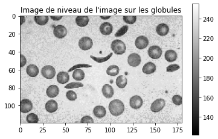

```python
image_globule = imread("cell.png",as_gray=True)
plt.imshow(image_globule, cmap="gray")
plt.title("Image de niveau de l'image sur les globules")
plt.colorbar()
plt.show()
```

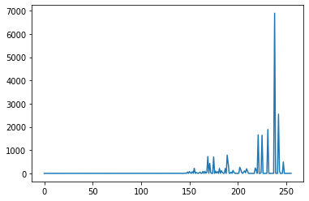

```python
myhist,bins = np.histogram(image_globule.ravel(),256,[0,255])
plt.plot(myhist)
plt.show()
```

```python
filteredimagename = filters.threshold_otsu(image_globule)
"notre seuil est : "+str(filteredimagename)
```

```
'notre seuil est : 206'
```

## Résultat du Seuillage avec filters.thereshold_otsu(image)

prenons à présent une image qui n'est pas bimodale : Lena.

[figure not shown]

```python
img_lena = plt.imread('lena1.jpg')
plt.imshow(img_lena,cmap="gray")
plt.colorbar()
plt.title("Image de niveau de gris de bonne qualité")
plt.show()
```

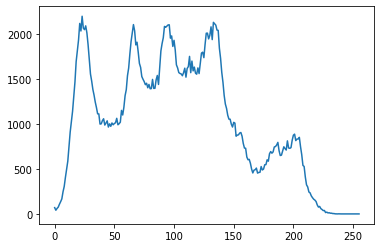

```python
myhist,bins = np.histogram(img_lena.ravel(),256,[0,255])
plt.plot(myhist)
plt.show()
```

[figure not shown]

```python
img = np.array(img_lena)

seuil_img = filters.threshold_otsu(img_lena)
retVal, newImg = cv2.threshold(img_lena, seuil_img, 255, cv2.THRESH_BINARY)
plt.imshow(img, cmap="gray")
plt.show()
```

[figure not shown]

```
Le seuil d'Otsu est :  101
```

```python
plt.imshow(newImg, cmap="gray")
plt.show()
print("Le seuil d'Otsu est : ", seuil_img)
```

on voit que le seuillage, ressort bien l'objet du fond. Et donc, contrairement à une image multimodal, une image à 1 seul mode est meilleur car on parvient à conserver les informations en rapport avec les formes ou objets de l'image.

# Retour sur l'image cell.png

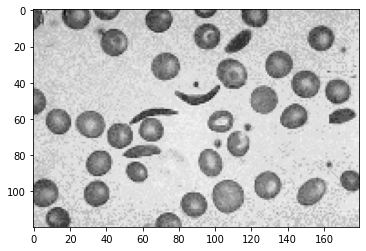

```python
img_glb = np.array(image_globule)

seuil_img = filters.threshold_otsu(image_globule)
(retVal, Globul_Bin) = cv2.threshold(image_globule, filteredimagename, 255, cv2.THRESH_BINARY)
plt.imshow(image_globule, cmap="gray")
plt.show()
```

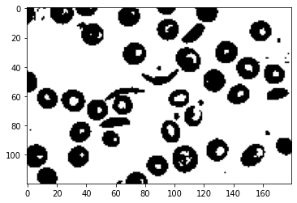

```
Le seuil d'Otsu est :  206
```

```python
plt.imshow(Globul_Bin, cmap="gray")
plt.show()
print("Le seuil d'Otsu est : ", seuil_img)
```

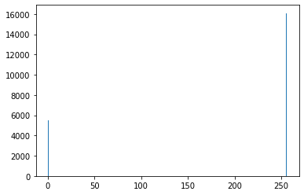

```python
plt.hist(Globul_Bin.ravel(),256,[0,256]);
plt.show()
```

### une analyse en composantes connexes pour compter le nombre de cellules, grâce à la fonction label, que vous pourrez trouver dans skimage.measure ou scipy.ndimage.measurements

### - avec Scipy.Ndimage.Measurements.Label

```python
labeled_array, num_features = label(Globul_Bin)
print("il y a : ", num_features, "cellules dans l'image cell.png")
```

```
il y a :  38 cellules dans l'image cell.png
```

### - avec Skimage.Measure

```python
labeled_array, num_features = measure.label(Globul_Bin, return_num=True)
print("il y a : ", num_features, "cellules dans l'image cell.png")
```

```
il y a :  34 cellules dans l'image cell.png
```

### - avec OpenCV.connectedComponentsWithStats

```python
n, labels, stats, _ = cv2.connectedComponentsWithStats(Globul_Bin)
print("il y a : ", n, "cellules dans l'image cell.png")
```

```
il y a :  35 cellules dans l'image cell.png
```

Et pourtant à l'oeil nu, on peut observer que notre image possède au moins 40 cellules, nous osons donc conclure que la metthode **label** de la classe **Measurements** du package **Ndimage** de la librairie **Scipy** nous donne plus au moins le meilleur résultat : 38. cellules

# Seuillage from scratch

```python
def otsu_th(im,nbins=255):
    bins = [np.count_nonzero(im==i)for i in range(256)]
    dim=im.size
    seuil=256
    sm=None
    sgm=[]
    #
    for i in range(256):
        class1 = im[np.where(im<=i)]
        class2 = im[np.where(im>i)]
        #
        O = (len(class1)/dim,len(class2)/dim)
        #
        if class1.size == 0 :
            class1 = [0]
        if class2.size == 0 :
            class2 = [0]
        var_ = (np.var(class1),np.var(class2))
        #
        sg = O[1]*var_[1]+O[0]*var_[0]
        sgm.append(sg)
        if sm is None or sg < sm :
            sm = sg
            seuil = i
    return seuil, sgm
```

```python
n,l=otsu_th(image_globule, nbins=255)
```

```
le seuil de la fonction implementée est: 206
```

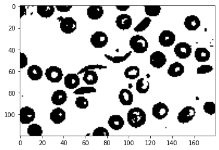

```python
print("le seuil de la fonction implementée est:", n)
plt.imshow(image_globule > n, cmap="gray")
```

On peut cosntater que **AVEC** notre code ou **SANS** notre code, le seuillage d'Otsu sur une image Bimodal donne le même résultat.

et donc si nous avons le même résultat en terme de seuil, à quoi plus forte raison de s'attendre au même résultat en terme de composantes connexes .

```python
labeled_array, num_features = label(image_globule > n)
print("il y a : ", num_features, "ce-llules dans l'image cell.png avec notre propre algorithgme de Otsu")
```

```
il y a :  38 ce-llules dans l'image cell.png avec notre propre algorithgme de Otsu
```

# Partie 2. Morphomaths

Appliquer des opérations de morphologie mathématiques pour nettoyer l'image texte.bmp. Justifier quelle opération appliquer avec quel élément structurant.

Quoi ?

Dans cette deuxième partie, on s'intérresse un peu comme à la partie précédente à l'extraction des structures présentent dans une image, à la différence que, ici nous allons appliquer un ensemble d'opération qui nous permettra par exemple de retirer le bruit c'est à dire de nettoyer l'image.

Comment ?

**Avec OpenCV**

1) Tout d'abord nous allons ouvrir l'image, l'observer, applique une inversion de celle-ci afin de mieux mettre en avant ce qui fait l'objet de notre analyse : les textes.

2) Ensuite, pour obtenir un meilleur résultat après dilatation, plusiseurs ouvrages nous recommande de commencer par une érosion, nous allons appliquer une érosion avec OpenCV afin de supprimer le bruit, l'élément structurant ici sera alors un carré.

3) Une fois le bruit supprimés, il faudrait maintenant dilater l'image, de façon à réparer les traits interrompus. On consatte alors qu'il nous rest eun point.

**Sans OpenCV : SKimage.area_closing (Non recommandé, nous l'avons juste utilisé pour l'expérience)**

4) Une seconde inversiokn est appliqué juste pour observer ce qui s'est passé par rapport à l'image de départ.

5) (Non demandé), on applique une area_closing, pour retirer ce point là afin d'avoir une image totalement propre.

Enfin, on se permet de montrer qu'il est possible à l'aide de la fermeture de Skimage d'obtenir un resultat parfait en une seule fois (chose qui n'a pas été demandé car on ignore ce qui se passe derrière)

Ouverture de l'image bmp :

```
On affiche l'image
```

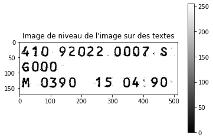

```
On Inverse l'image
```

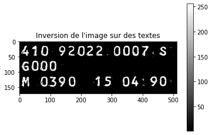

```python
print("On affiche l'image")
print("")
txt_image =imread("text.bmp")
plt.imshow(txt_image, cmap="gray")
plt.title("Image de niveau de l'image sur des textes")
plt.colorbar()
plt.show()

print("On Inverse l'image")
print("")
txt_image_inv = 256-txt_image
plt.imshow(txt_image_inv, cmap="gray")
plt.title("Inversion de l'image sur des textes")
plt.colorbar()
plt.show()
```

```
On applique une erosion
```

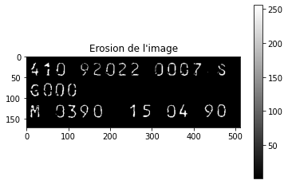

```python
print("On applique une erosion")
print("")
kernel = np.ones((3,3),np.uint8)
txt_erode = cv2.erode(txt_image_inv,kernel,iterations = 1)
plt.title("Erosion de l'image")
plt.imshow(txt_erode, cmap="gray")
plt.colorbar()
plt.show()
```

```
On applique une dilatation
```

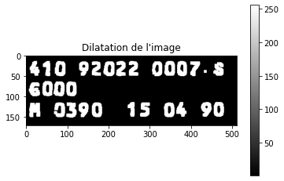

```python
print("On applique une dilatation")
print("")
kernel = np.ones((4,4),np.uint8)
txt_dilate = cv2.dilate(txt_erode,kernel,iterations = 2)
plt.title("Dilatation de l'image")
plt.imshow(txt_dilate, cmap="gray")
plt.colorbar()
plt.show()
```

```
On applique une inversion juste pour voir, ce qu'on obtient contrairement à la prmeière image
```

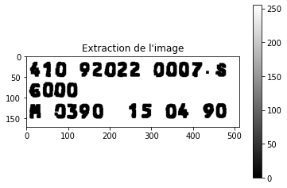

```python
print("On applique une inversion juste pour voir, ce qu'on obtient contrairement à la prmeière image ")
print("")
txt_extract_inv = 256-txt_dilate
plt.imshow(txt_extract_inv, cmap="gray")
plt.title("Extraction de l'image")
plt.colorbar()
plt.show()
```

```
On applique une fermeture
```

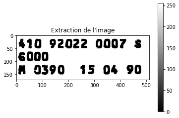

```python
print("On applique une fermeture")
print("")
kernel = np.ones((2,2),np.uint8)
txt_extraction = morphology.area_closing(txt_extract_inv)
plt.title("Extraction de l'image")
plt.imshow(txt_extraction, cmap="gray")
plt.colorbar()
plt.show()
```

#### En définitif, peut importe le nombre d'opération successif qu'on effectue, on garde quand même un minimum de bruit ! Par ailleurs, on peut à l'aide d'une fonction non apprise durnat le cours obtenir un meilleur résultat :

```
On applique une fermeture
```

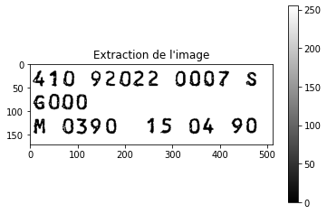

```python
print("On applique une fermeture")
print("")
kernel = np.ones((3,3),np.uint8)
txt_extraction = morphology.area_closing(txt_image)
plt.title("Extraction de l'image")
plt.imshow(txt_extraction, cmap="gray")
plt.colorbar()
plt.show()
```

## Partie 3. Composantes connexes et descripteurs de forme

L'objectif de la troisième partie est de pouvoir décrire les caractéristiques des objets que l'on trouve dans une image, ces caractéristiques peuvent être l'orientation, le diametre, le périmètre, etc.

```python
coins = data.coins()
```

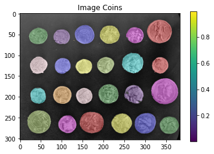

```python
plt.title("Image Coins")
plt.imshow(coins, cmap="gray")

# Make segmentation using edge-detection and watershed.
edges = sobel(coins)

# Identify some background and foreground pixels from the intensity values.
# These pixels are used as seeds for watershed.
markers = np.zeros_like(coins)
foreground, background = 1, 2
markers[coins < 30.0] = background
markers[coins > 150.0] = foreground

ws = watershed(edges, markers)
seg1 = measure.label(ws == foreground)

color1 = label2rgb(seg1, image=coins, bg_label=0)
plt.imshow(color1)
plt.colorbar()
plt.show()
```

Utilisons l'image en Niveau de Gris (**NDG**) :

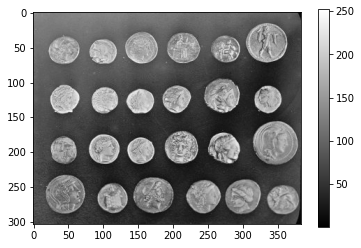

```python
plt.imshow(coins, cmap="gray")
plt.colorbar()
plt.show()
```

```python
coins_rtv, coins_thr = cv2.threshold(coins,0,255,cv2.THRESH_BINARY+cv2.THRESH_OTSU)
```

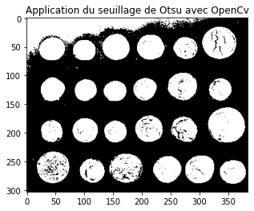

```python
plt.title("Application du seuillage de Otsu avec OpenCv")
plt.imshow(coins_thr, cmap="gray")
```

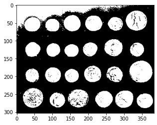

```python
otsu_thresh = filters.threshold_otsu(coins)
binary_otsu = coins > otsu_thresh
binary_otsu

plt.imshow(binary_otsu, cmap="gray")
```

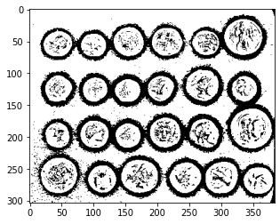

```python
block_size = 35
local_th = coins > filters.threshold_local(coins, block_size, offset=10)
plt.imshow(local_th, cmap="gray")
```

## Nettoyage

On utilise **clear border** pour effacer les liens au niveau des bordures, aavnt d'effacer les artefacts restant.

```
il y a :  24 pièces dans coins
```

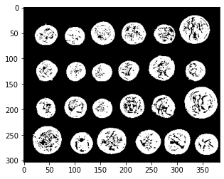

```python
image_clean = clear_border(local_th)

image_clean = morphology.remove_small_objects(image_clean, min_size=15)

plt.imshow(image_clean, cmap="gray")

labeled_array, num_features = measure.label(image_clean, return_num=True)
print("il y a : ", num_features, "pièces dans coins")
```

```
il y a :  24 pièces dans coins
```

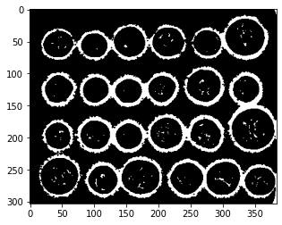

```python
dilation2 = morphology.dilation(local_th)

plt.imshow(dilation2,cmap="Greys")

labeled_array, num_features = measure.label(dilation2, return_num=True)
print("il y a : ", num_features, "pièces dans coins")
```

```
il y a :  24 pièces dans coins
```

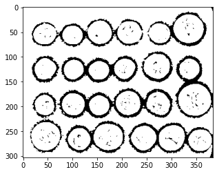

```python
dilation2 = morphology.dilation(local_th)

plt.imshow(dilation2,cmap="gray")

labeled_array, num_features = measure.label(dilation2, return_num=True)
print("il y a : ", num_features, "pièces dans coins")
```

# Propriétés

```python
from skimage.measure import label, regionprops
```

```python
label_img = label(local_th)
regions = regionprops(label_img)

props = []
print("Les autres ropriétés : ")
print("")
for i in regions[0]:
    props.append(i)
print(props)

centroids = [prop.centroid for prop in regions]
diametres = [prop.equivalent_diameter for prop in regions]

centroid = regions[9].centroid
labell = regions[9].label
area = regions[9].area
orientation = regions[9].orientation
diametre = regions[9].equivalent_diameter

print("")

print("Analysons la 10e pièce de l'image :")
print("*********************************")
print("")
print("pour la pièce numéro "+str(label)+" situé dans la région : "+str(area)+", orientation de : "+str(orientation)+" cette pièce est de diamètre "+str(diametre)+" et de valeur de centroid" +str(centroid))
```

```
Les autres ropriétés :

['area', 'bbox', 'bbox_area', 'centroid', 'convex_area', 'convex_image', 'coords', 'eccentricity', 'equivalent_diameter', 'euler_number', 'extent', 'filled_area', 'filled_image', 'image', 'inertia_tensor', 'inertia_tensor_eigvals', 'label', 'local_centroid', 'major_axis_length', 'minor_axis_length',…

Analysons la 10e pièce de l'image :

pour la pièce numéro <function label at 0x7f98368f0378> situé dans la région : 1, orientation de : 0.7853981633974483 cette pièce est de diamètre 1.1283791670955126 et de valeur de centroid(32.0, 198.0)
```

## Partie 4. La transformée de Hough

Dans cette partie, l'objectif est de faire de nous des datascientist capable de detecter des chemins afin de permettre par exemple à des véhicules autonomes de pouvoir respecter les structures de routes et donc de rester ur la trajectoire de celle-ci. Pour se faire, l'idée principale est de binariser les images pour ensuite, repérer les lignes des chemins afin de constituer des bandes, pour y parvenir nous tentons d'appliquer implicitement (pour des raisons de temps), la transformée de hough.

1) Commençons par ouvrir notre image, la transformer en NDG.

2) Ensuite trouvons le seuil et binarisons l'image.

3) Binariser l'image va nous permettre de trouver les contours, on sinterressera alors aux lignes de notre image qui proviendra d'une matrice cereuse.

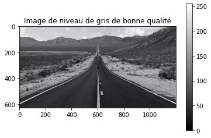

```python
route = plt.imread('routendg3.jpeg')
# notre image n'est pas en NDG
route_ndg = cv2.cvtColor(route, cv2.COLOR_RGB2GRAY)
plt.imshow(route, cmap="gray")
plt.colorbar()
plt.title("Image de niveau de gris de bonne qualité")
plt.show()
```

```python
route_ndg.shape
```

```
(627, 1200)
```

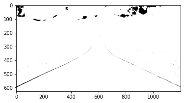

```python
_, binary = cv2.threshold(route_ndg, 225, 255, cv2.THRESH_BINARY_INV)
plt.imshow(binary, cmap="gray")
plt.show()
```

```python
_
```

```
225.0
```

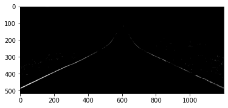

```python
new_img = np.copy(255-binary[110:,:])
plt.imshow(new_img, cmap="gray")
plt.show()
```

```python
print(new_img)
print(new_img.shape)
```

```
[[0 0 0 ... 0 0 0]
 [0 0 0 ... 0 0 0]
 [0 0 0 ... 0 0 0]
 ...
 [0 0 0 ... 0 0 0]
 [0 0 0 ... 0 0 0]
 [0 0 0 ... 0 0 0]]
(517, 1200)
```

```python
from PIL import Image
```

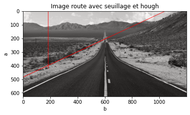

```python
gray = np.copy(new_img)

#extraction des contours présents dans l'image binarisé
edges = cv2.Canny(new_img,50,150,apertureSize = 3)

# HOUGH au seuil _ : 225
lines = cv2.HoughLines(new_img,1,np.pi/180,int(_))

for rho,theta in lines[0]:
    a = np.cos(theta)
    b = np.sin(theta)
    x0 = a*rho
    y0 = b*rho
    x1 = int(x0 + 1000*(-b))
    y1 = int(y0 + 1000*(a))
    x2 = int(x0 - 1000*(-b))
    y2 = int(y0 - 1000*(a))

    cv2.line(route,(x1,y1),(x2,y2),(0,0,255),2)

cv2.imwrite('aaa_RouteHough.png',route)
route_hough = plt.imread('aaa_RouteHough.png')
plt.imshow(route_hough)
plt.xlabel("b")
plt.ylabel("a")
plt.title("Image route avec seuillage et hough")
plt.show()
```

## Partie 5. Mise en oeuvre d'une chaîne complète : prétraitement, extraction de caractéristiques, ditsance entre échantillon

L'objectif de la partie 5 est de calculer des descripteurs, et de voir si entre 2 items d'une même catégorie la distance est bien faible, et entre 2 items n'appartenant pas à cette catégorie, la distance est importante.

# Parties des nombres

```python
One1_img = cv2.imread("one1.png")
Two1_img = cv2.imread("two1.png")
One2_img = cv2.imread("one2.png")
Two2_img = cv2.imread("two2.png")
One3_img = cv2.imread("one3.png")
Two3_img = cv2.imread("two3.png")
```

### On commences d'abord par extraire les contours avec Canny

```python
edgeOne1 = cv2.Canny(One1_img,100,200)
edgeOne2 = cv2.Canny(One2_img,100,200)
edgeOne3 = cv2.Canny(One3_img,100,200)
edgeTwo1 = cv2.Canny(Two1_img,100,200)
edgeTwo2 = cv2.Canny(Two2_img,100,200)
edgeTwo3 = cv2.Canny(Two3_img,100,200)
edgeOne1 = 255- edgeOne1
edgeOne2 = 255- edgeOne2
edgeOne3 = 255- edgeOne3
```

##### Exemple du contour résultant de l'image one1

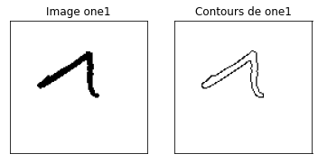

```python
plt.subplot(121)
plt.imshow(One1_img,cmap = 'gray')
plt.title("Image one1")
plt.xticks([]), plt.yticks([])
plt.subplot(122)
plt.imshow(edgeOne1,cmap = 'gray')
plt.title("Contours de one1")
plt.xticks([]), plt.yticks([])
plt.show()
```

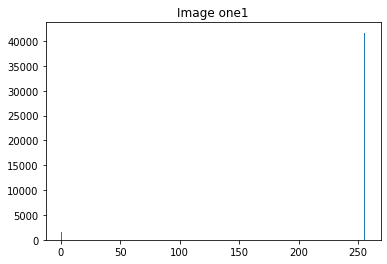

```python
plt.title("Image one1")
plt.hist(np.ravel(One1_img),256,[0,256])
```

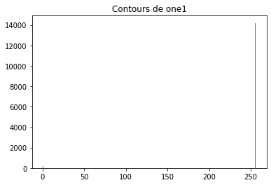

```python
plt.figure()
plt.title("Contours de one1")
plt.hist(np.ravel(edgeOne1),256,[0,256])
```

#### Comparer la ressemblance entre les images one1 et one2

```python
from scipy.ndimage import gaussian_filter
from skimage.color import rgb2gray
from scipy.spatial import distance
```

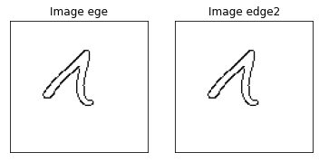

```python
plt.subplot(121)
plt.imshow(edgeOne2,cmap = 'gray')
plt.title("Image ege")
plt.xticks([]), plt.yticks([])
plt.subplot(122)
plt.imshow(edgeOne2,cmap = 'gray')
plt.title("Image edge2")
plt.xticks([]), plt.yticks([])
plt.show()
```

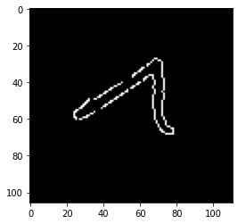

```python
matrice1 = np.zeros((len(edgeOne2),len(edgeOne2[0])))
for i in range(len(edgeOne2)):
    for j in range(len(edgeOne2[0])):
        matrice1[i][j] = distance.euclidean(edgeOne2[i][j],edgeOne1[i][j])

plt.imshow(matrice1, cmap = "gray")
```

#### Comparer la ressemblance entre les images one1 et two1

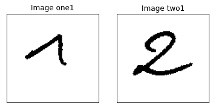

```python
plt.subplot(121)
plt.imshow(One1_img,cmap = 'gray')
plt.title("Image one1")
plt.xticks([]), plt.yticks([])
plt.subplot(122)
plt.imshow(Two1_img,cmap = 'gray')
plt.title("Image two1")
plt.xticks([]), plt.yticks([])
plt.show()
```

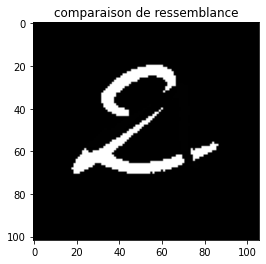

```python
matrice2 = np.zeros((len(Two1_img),len(Two1_img[0])))
for i in range(len(One1_img) - 20):
    for j in range(len(One1_img[0]) - 16):
        # différence des distances
        matrice2[i][j] = np.linalg.norm(One1_img[i][j]-Two1_img[i][j])

plt.imshow(matrice2, cmap='gray')
plt.title("comparaison de ressemblance")
plt.show()
```